# Taller Día 1

Jemp

21/10/2021

# 1 Objetivo

Análisis de los mercados financieros a través de R.

# 2 Librerías

```r
library(quantmod) # permite vincular R con algunos portales de finanzas como Yahoo Finance
library(fBasics) # estadísticos
library(psych) # estadísticos
library(readxl) # para poder importar datos de excel
library(writexl) # para exportar objetos a excel
library(stats) # estadísticos
library(nortest) # para aplicar pruebas de normalidad
library(imputeTS) # permite interpolar datos
library(scales) # permite ponerle caracteres especializados a los resultados
```

# 3 Arreglo de Datos

```r
getSymbols(Symbols= c("MXN=X", "BRL=X", "EURUSD=X"), from="2019-01-01", to="2021-09-30",
           periodicity= "daily", src= "yahoo")
```

[output not shown]

```
## [1] "MXN=X"    "BRL=X"    "EURUSD=X"
```

```r
divisas<-Ad(merge(`MXN=X`,`BRL=X`,`EURUSD=X`))
```

```r
names(divisas)<-c("USDMXN","USDBRL","EURUSD")
```

Arreglos Matriciales: [n,m] … n renglones, m columnas

##Verificación de espacios en blanco (NA)

```r
divisas[!complete.cases(divisas),]
```

```
##            USDMXN USDBRL EURUSD
## 2019-05-22     NA     NA     NA
```

```r
divisas.na<-na.omit(divisas)
```

# 4 Visualización

## 4.1 Peso Mexicano

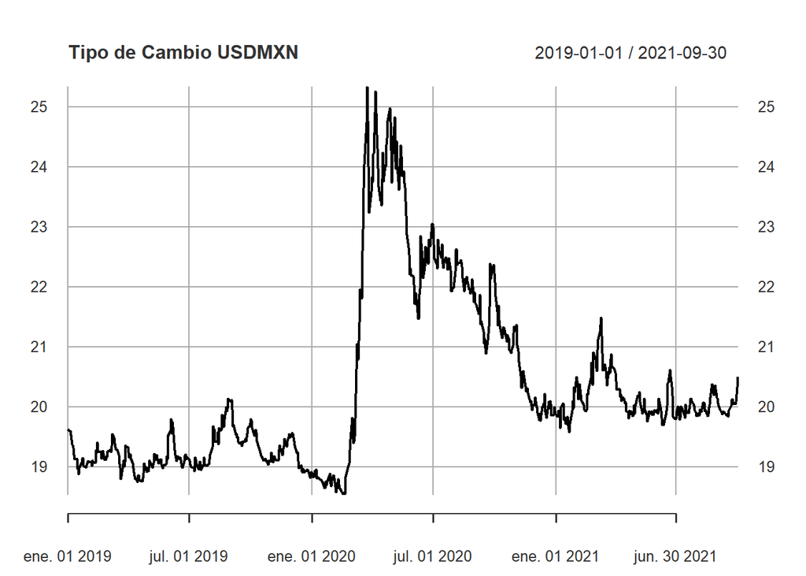

```r
plot(divisas.na$USDMXN, type="l", main="Tipo de Cambio USDMXN")
```

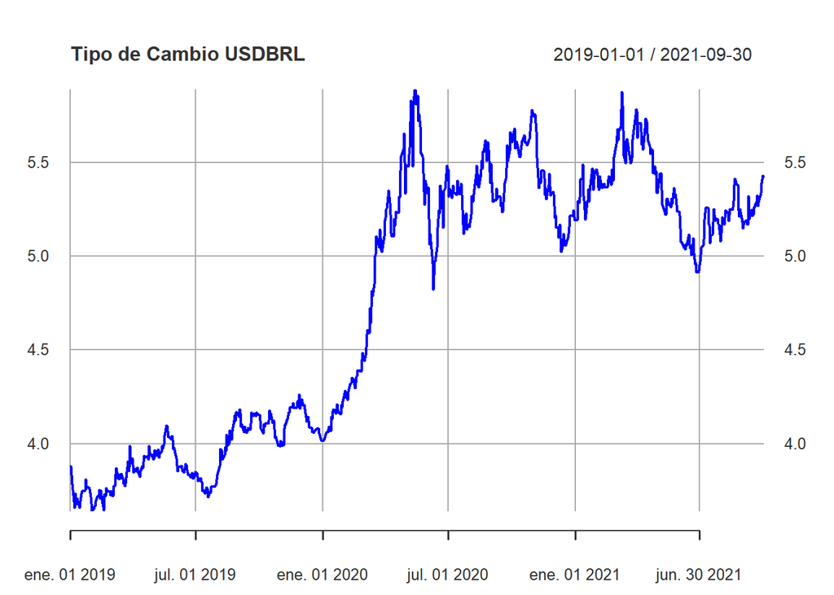

```r
plot(divisas.na$USDBRL, type="l", main="Tipo de Cambio USDBRL", col="blue")
```

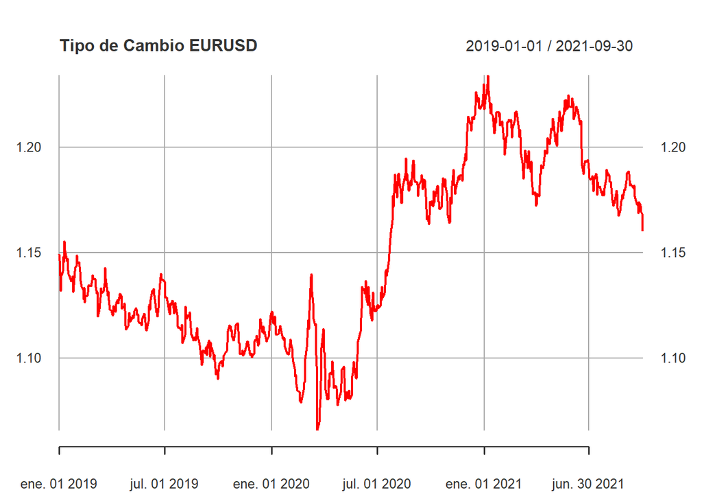

```r
plot(divisas.na$EURUSD, type="l", main="Tipo de Cambio EURUSD", col="red")
```

## 4.2 Histogramas

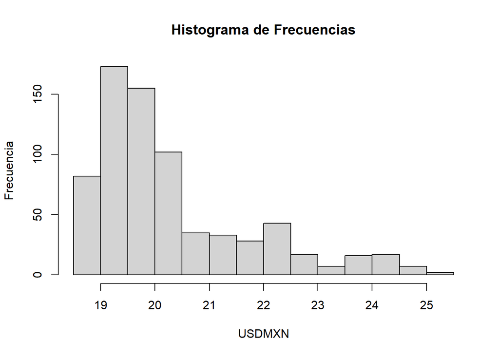

```r
hist(divisas.na$USDMXN, main="Histograma de Frecuencias", ylab="Frecuencia", xlab= "USDMXN")
```

```r
library(ggExtra)
library(ggplot2)
divisas.df<-data.frame(divisas.na)
```

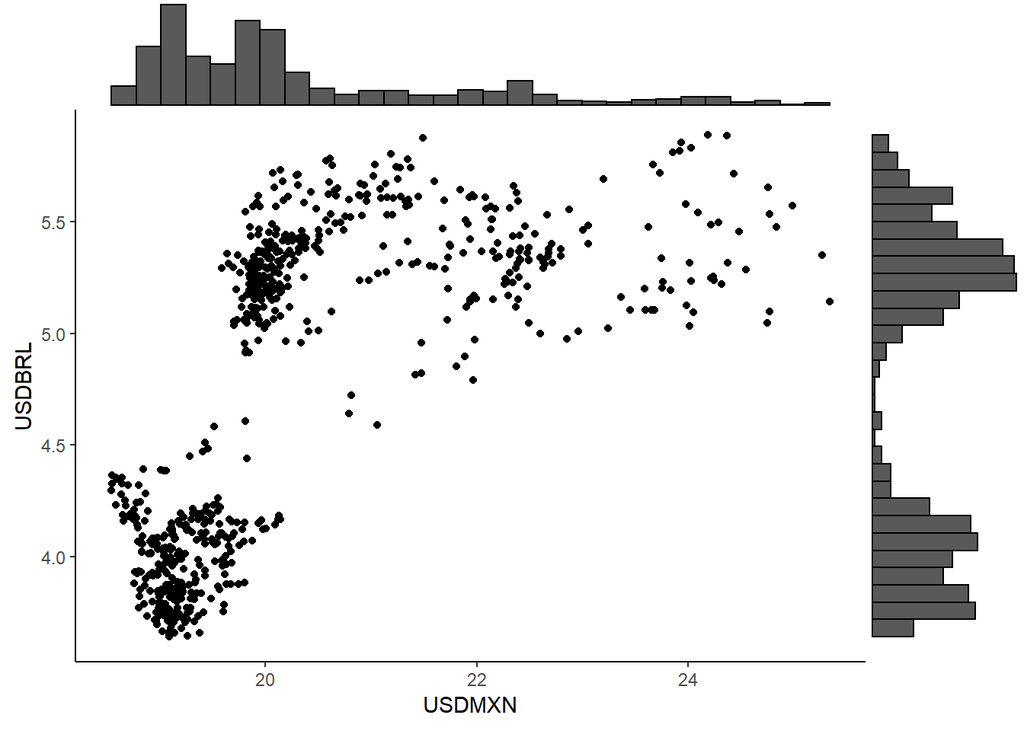

```r
## aes  quiere decir aesthetics
h.mxnbrl <- ggplot(divisas.df, aes(x=USDMXN, y=USDBRL)) + geom_point() + theme_classic()
ggMarginal(h.mxnbrl, type= "histogram")
```

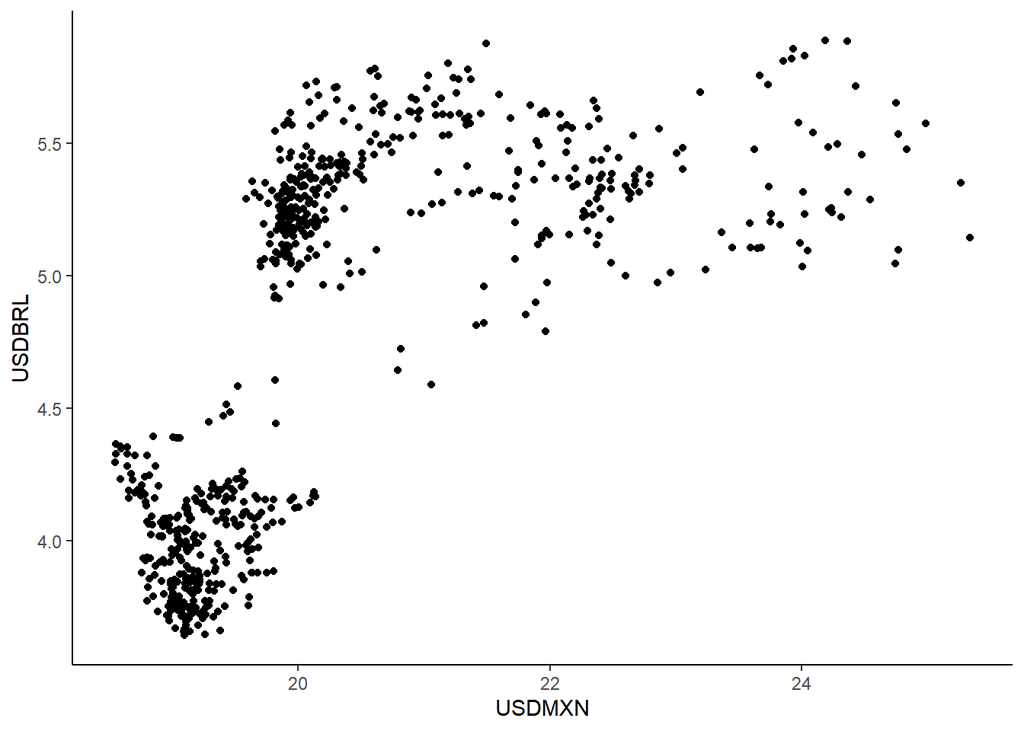

```r
h.mxnbrl
```

```r
obs<-nrow(divisas.df)
## seq: sequence
xx<-seq(1,obs,1)
```

```r
dfmxn<-data.frame(x=xx,y=divisas.df$USDMXN,type="MXN")
dfbrl<-data.frame(x=xx,y=divisas.df$USDBRL,type="BRL")
df<-rbind(dfmxn,dfbrl)
```

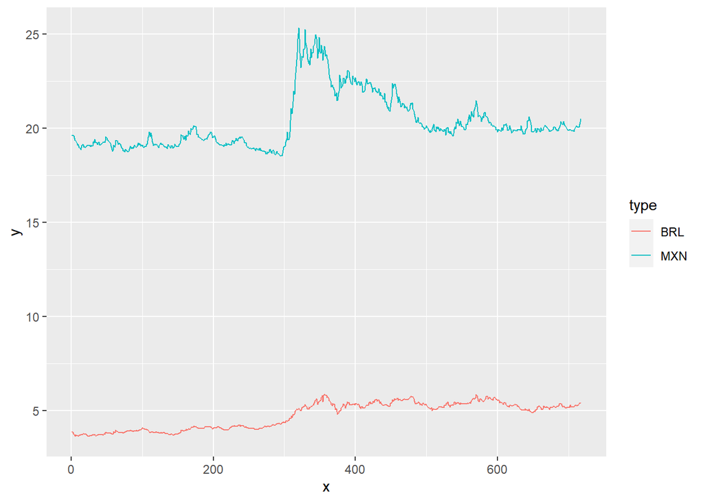

```r
ggplot(df) +
  geom_line(aes(x,y,colour=type))
```

No Estacionariedad: Cuando la variable lleva tendencia Hacer que la variable sea estacionaria (No Tendencia)

#Cambios Porcentuales $Diferencia=P_h-P_a$

Primero construimos las diferencias

```r
divisas.diff<-diff(divisas.na,lag=1)
```

LaTex

$\frac{P_h-P_a}{P_a}$

```r
divisas.rets<-(divisas.diff/divisas.na[-1,])
```

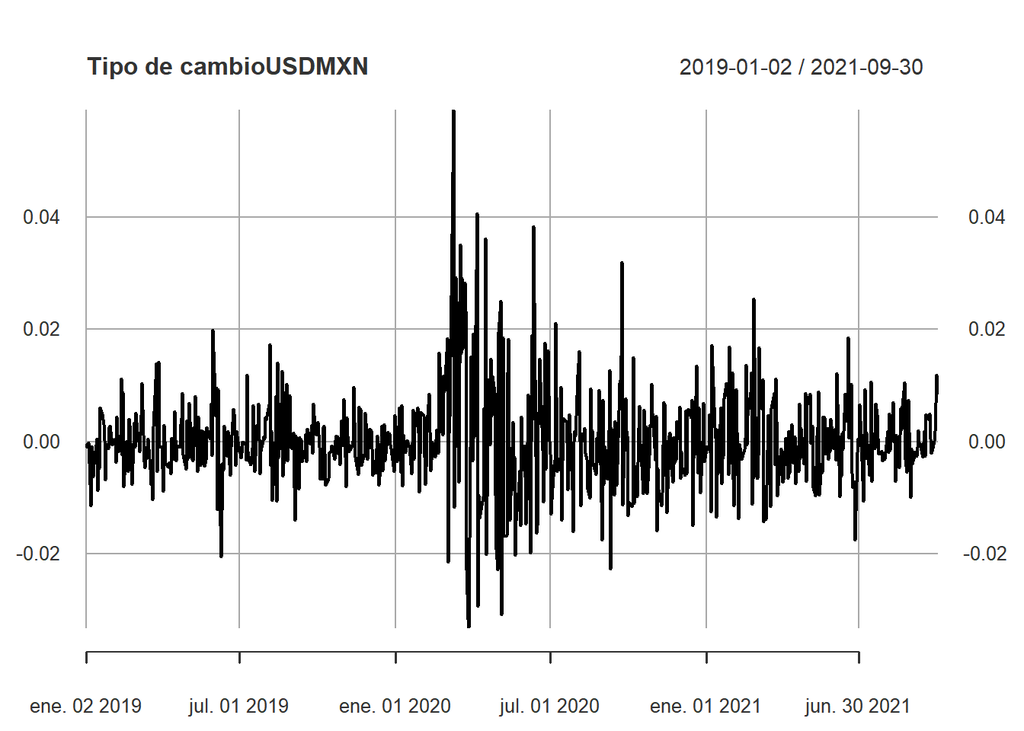

```r
plot(divisas.rets$USDMXN,type="l",main="Tipo de cambioUSDMXN")
```

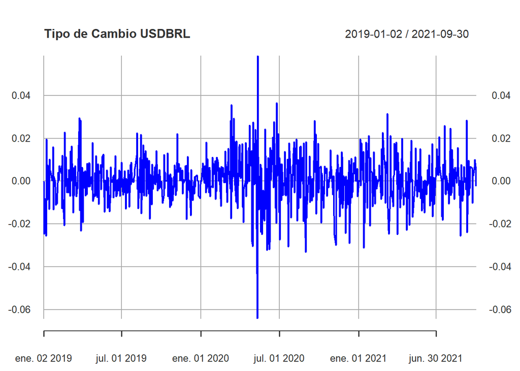

```r
plot(divisas.rets$USDBRL,type="l",main="Tipo de Cambio USDBRL",col="blue")
```

```r
rets.df<-data.frame(divisas.rets)
```

Lo siguiente permite combinar el gráfico original del tipo de cambio y los valores de los cambios porcentuales.

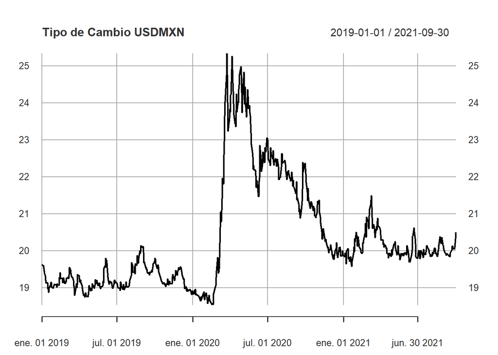

```r
plot(divisas.na$USDMXN,main="Tipo de Cambio USDMXN")
```

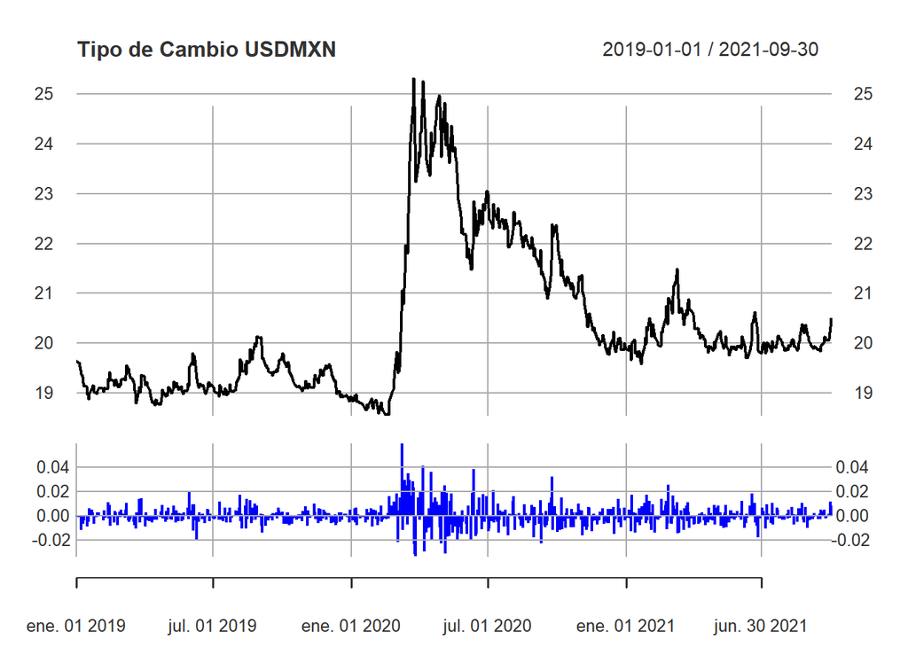

```r
lines(divisas.rets$USDMXN,type="h",on=NA,col="blue")
```

Hechos estilizados (Stylized Facts), Feather vs Rocket

## 4.3 Exportamos a Excel

```r
write_xlsx(rets.df,"retsdivisas.xlsx")
```

#Análisis Estadístico Conocer estadísticos básicos

```r
summary(divisas.rets)
```

```
##      Index                USDMXN               USDBRL
##  Min.   :2019-01-02   Min.   :-3.318e-02   Min.   :-0.0642174
##  1st Qu.:2019-09-10   1st Qu.:-4.142e-03   1st Qu.:-0.0062841
##  Median :2020-05-18   Median :-4.772e-04   Median : 0.0003438
##  Mean   :2020-05-17   Mean   : 2.183e-05   Mean   : 0.0004002
##  3rd Qu.:2021-01-22   3rd Qu.: 3.728e-03   3rd Qu.: 0.0066557
##  Max.   :2021-09-30   Max.   : 5.903e-02   Max.   : 0.0584656
##      EURUSD
##  Min.   :-2.854e-02
##  1st Qu.:-2.299e-03
##  Median : 3.570e-05
##  Mean   : 5.554e-06
##  3rd Qu.: 2.254e-03
##  Max.   : 1.436e-02
```

Una mejor instrucción es “describe” (libreria: psych)

```r
describe(divisas.rets)
```

```
##        vars   n mean   sd median trimmed  mad   min  max range  skew kurtosis
## USDMXN    1 716    0 0.01      0       0 0.01 -0.03 0.06  0.09  0.89     5.45
## USDBRL    2 716    0 0.01      0       0 0.01 -0.06 0.06  0.12 -0.13     2.51
## EURUSD    3 716    0 0.00      0       0 0.00 -0.03 0.01  0.04 -0.43     4.27
##        se
## USDMXN  0
## USDBRL  0
## EURUSD  0
```

Sesgo: Si el valor es positivo entonces es una distribución cargada a la derecha, esto es, han ocurrido mayormente valores positivos que negativos. Contrario, si el valor es negativo entonces la distribución es cargada a la izquierda, esto es, mayormente han ocurrido valores negativos que positivos. Curtosis: Si el valor es mayor que 3 entonces se le conoce como leptokurtica (presencia de valores extremos)

#Pruebas de Normalidad Prueba de Lilliefors

```r
lillie.test(divisas.rets$USDMXN)
```

```
##
##  Lilliefors (Kolmogorov-Smirnov) normality test
##
## data:  divisas.rets$USDMXN
## D = 0.88138, p-value < 2.2e-16
```

H0: La distribución es normal (p-value>0.05 entonces NO se rechaza la H0) H1: No distribución Normal (p-value<0.05, entoncespara no aceptar la H0)

```r
lillie.test(divisas.rets$EURUSD)
```

```
##
##  Lilliefors (Kolmogorov-Smirnov) normality test
##
## data:  divisas.rets$EURUSD
## D = 0.97753, p-value < 2.2e-16
```

```r
pearson.test(divisas.rets$EURUSD)
```

```
##
##  Pearson chi-square normality test
##
## data:  divisas.rets$EURUSD
## P = 34.291, p-value = 0.1018
```

La hipotesis nula H0: Los rendimientos se distribuyen como una normal. La hipotesis alterna H1: Los rendimientos NO se distribuyen como una normal.

Interpretación: Si el p-value es mayor que 0.05 entonces no se rechaza la H0; si el p-value es menor que 0.05 entonces si se rechaza la H0. Los rendimientos del USDMXN no se distribuyen como una normal.

Prueba de Pearson

```r
pearson.test(divisas.rets$USDMXN)
```

```
##
##  Pearson chi-square normality test
##
## data:  divisas.rets$USDMXN
## P = 107.03, p-value = 4.006e-12
```

##Análisis Multivariado

```r
divisas.df.cor<-cor(divisas.df)
divisas.df.cor
```

```
##             USDMXN    USDBRL      EURUSD
## USDMXN  1.00000000 0.6661145 -0.04644833
## USDBRL  0.66611447 1.0000000  0.57354453
## EURUSD -0.04644833 0.5735445  1.00000000
```

```r
divisas.cor<-cor(divisas.rets)
divisas.cor
```

```
##            USDMXN     USDBRL     EURUSD
## USDMXN  1.0000000  0.4450427 -0.2942980
## USDBRL  0.4450427  1.0000000 -0.2350477
## EURUSD -0.2942980 -0.2350477  1.0000000
```

```r
library(ggcorrplot)
```

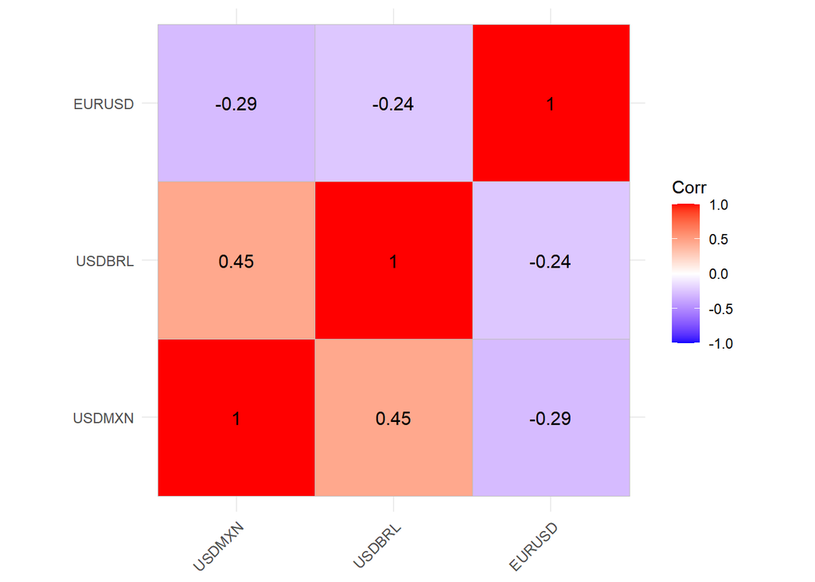

```r
ggcorrplot(divisas.cor,tl.cex=9,lab=TRUE,lab_size = 4)
```

##Modelo de Regresión

```r
mrl.mxnbrl<-lm(USDMXN~USDBRL+EURUSD,data=divisas.rets)
summary(mrl.mxnbrl)
```

```
##
## Call:
## lm(formula = USDMXN ~ USDBRL + EURUSD, data = divisas.rets)
##
## Residuals:
##       Min        1Q    Median        3Q       Max
## -0.036595 -0.003705 -0.000317  0.003367  0.066648
##
## Coefficients:
##               Estimate Std. Error t value Pr(>|t|)
## (Intercept) -9.788e-05  2.868e-04  -0.341    0.733
## USDBRL       3.054e-01  2.585e-02  11.815  < 2e-16 ***
## EURUSD      -4.515e-01  7.572e-02  -5.963 3.91e-09 ***
## ---
## Signif. codes:  0 '***' 0.001 '**' 0.01 '*' 0.05 '.' 0.1 ' ' 1
##
## Residual standard error: 0.007668 on 713 degrees of freedom
## Multiple R-squared:  0.2362, Adjusted R-squared:  0.234
## F-statistic: 110.2 on 2 and 713 DF,  p-value: < 2.2e-16
```